# Time Series Mid-Term Exam

Chris Montgomery

11/28/2018

Problem I

The below equation models a random walk process.

$$y_t = y_{t-1} + w_t$$
Assuming a mean of zero, variance $\sigma^2$, and zero autocorrelation for the white noise term, the uncondutional mean of the series can be shown as follows:

$$E[y_t] = E[y_{t-1}] + E[w_t]$$
$$E[y_{t-1}] = E[y_{t-2}] + E[w_{t-1}]$$
$$E[y_{t}] = E[y_{t-2}] + E[w_t] + E[w_{t-1}]$$
$$E[y_{t}] = E[w_t] + E[w_{t-1}] + E[w_{t-2}].... + E[w_0]$$
$$E[y_t] = 0$$

The value of a random walk at any time t is simply the summation of the expectation of the random noise term at time t and all previous noise terms. Based on the above assumption of a non-autocorrelated mean zero white noise series, we know the expectation of each noise term is zero. Thus the unconditional mean of a random walk at time t, is likewise zero. The unconditional variance of the random walk process is simply t$\sigma^2$. This represents the summation of all the variances of the white noise terms in the sequence.

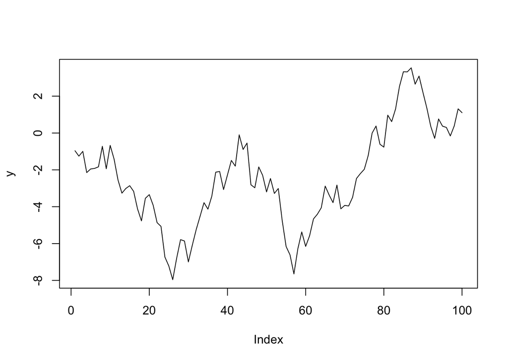

```r
set.seed (3)

y <-w  <- rnorm(100)

for (t in 2:100){
  y[t] <- y[t-1] + w[t]
}

plot(y, type = "l")
```

```r
var (y[1:5])
```

```
## [1] 0.3052617
```

The conditional mean and variance of the simulated series is -1.46 and .3 respectively at t = 5.

If I were to believe an asset’s price followed a random walk I would not attempt to forecast its future value. In a random walk model the only thing that affects the present value of a series is an unknown present shock. As such, it’s impossible to use previous information to predict future values. This concept essentially underpins the Efficient Market Hypothesis.

Problem II

Consider the following equation:
$$x_t = 3 - .5x_{t-1}$$

a.) The above function is stationary in the mean. We know this because we have an AR(1) series with an $a_1$ parameter < 1. The long run mean can be obtained from the function:
$$Mean(x_t) = a_0/(1-a1)$$
$$= 3/(1+ .5)$$
$$= 2$$

Simulation further demonstrates the mean of the above series converges to 2

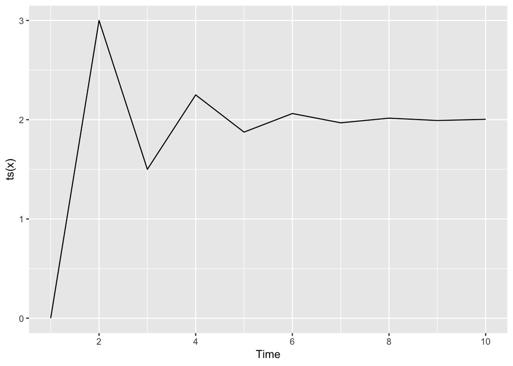

```r
set.seed(3)
x <- rnorm(10)
x[1] = 0
for (t in 2:10){
  x[t] <- 3 -.5*x[t-1]

}
autoplot(ts(x))
```

```r
x[4]
```

```
## [1] 2.25
```

```r
x
```

```
##  [1] 0.000000 3.000000 1.500000 2.250000 1.875000 2.062500 1.968750
##  [8] 2.015625 1.992188 2.003906
```

While the long run mean of the series is 2, we should note that the series requires several iterations before reaching equillibrium. For example, the above simulation shows $x_4$ = 2.25. In fact, the series continuously oscillates around the long run mean as it converges to the mean, a characteristic of the negative $a_1$ parameter.

Problem III

$$x_t = 3 + w_t = .5w_{t-1}$$
The above function represents a first-order moving average process, where $W$ represents a white noise sequence (0, $\sigma^2$). We know this function is mean stationary because it is composed of a constant added to a white noise process with an unconditional mean of 0. Remember, for all values of t
$$E[w_t] = E[ w_t + .5w_{t-1}] \\= E[w_t] + E[w_{t-1}]\\ = 0$$
and
$$E[x_t] = 3 + E[w_t]\\ = 3$$
Thus, given the above MA(1) process with an intercept term of 3, the expected unconditional mean is 3. Simulating this process supports the expectation of stationarity and the theorized mean of 3.

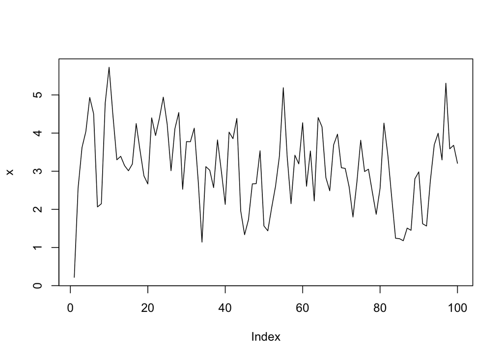

```r
set.seed(4)
x <- w <- rnorm(100)
for (t in 2:100){
  x[t] <- 3 + w[t] + (.5 * w[t-1])
}
plot(x, type = "l")
```

```r
mean(x)
```

```
## [1] 3.116175
```

Augmented Dickey Fuller test further demonstrates that the MA(1) process is stationary. We reject the null hypothesis of non-stationarity at the .1 level. Simulating with additional observations reduces the p-value further, which is to be expected.

```r
adf.test(x)
```

```
##
##  Augmented Dickey-Fuller Test
##
## data:  x
## Dickey-Fuller = -3.2692, Lag order = 4, p-value = 0.08026
## alternative hypothesis: stationary
```

A theoretic confidence interval can be derived from the function’s expected mean and variance. As demonstrated above, we know the expected mean is 3. The expected variance of the function can be defined by $VAR[x_t] = \sigma^2(\beta_0^2 + \beta_1^2)$ where $\sigma^2$ represents the variance of the white noise process and $\beta_0$ and $\beta_1$ represent the coefficients of each moving average term. With this we can derive the expected standard deviation of the function and by extension, a theoretical confidence interval.

$$\begin{aligned}
VAR[x_t] = \sigma^2 (\beta_0^2 + \beta_1^2) \\
= 1( 1^2 + .5^2) \\
= 1.25 \\
\end{aligned}$$
$$\begin{aligned}
Standard Deviation [x_t] = \sqrt{1.25} \\
\end{aligned}$$
$$\begin{aligned}
95\% Confidence Interval = 3\pm 1.96 *\sqrt{1.25} \\
= (.8,5.19)
\end{aligned}$$
Calculating the theoretical 95% confidence interval of the function near approximates the CI observed from the simulated data.

```r
#Calculate the 95% CI of the simulated function

upperbound <- mean(x) + (1.96 *var(x))
lowerbound <- mean(x) - (1.96 *var(x))

print(c(lowerbound,upperbound))
```

```
## [1] 0.8682802 5.3640701
```

Part IV

The main focus in this problem is to provide a model that can best fit a series that has conditional heteroskedacity. The following will demonstrate techniques for identifying autocorrelation of variance and fitting a General Autoregressive Conditional Heteroskedacity (GARCH) model to ARIMA residuals.

step 1.) Load and inspect the data

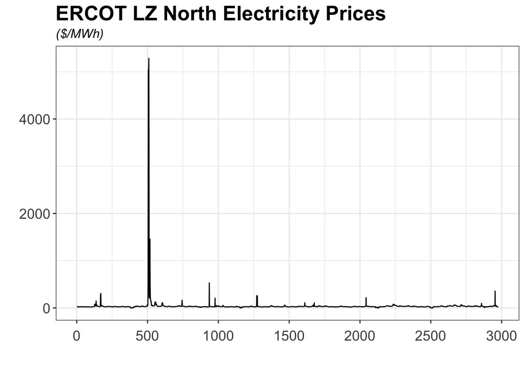

```r
df <- read.csv("ERCOT LZ North January 2014.csv")
ts <- ts(df$Settlement.Point.Price)

autoplot(ts) + theme_bw()+
labs(title="ERCOT LZ North Electricity Prices", subtitle="($/MWh)", y="", x="", caption="")+
  theme(plot.title = element_text( face = "bold", size = "19.5"))+
  theme(plot.subtitle = element_text( face = "italic", size = "12"))+
  theme(axis.text.x =element_text(size=13.5, vjust = -.75)
        , axis.text.y = element_text(size = 13.5 ),
        legend.title=element_text(face = "bold",size=11),
        legend.text=element_text(size=10, face = "bold"),
        plot.caption = element_text (size = 12))
```

```r
adf.test(ts); PP.test(ts)
```

```
##
##  Augmented Dickey-Fuller Test
##
## data:  ts
## Dickey-Fuller = -12.813, Lag order = 14, p-value = 0.01
## alternative hypothesis: stationary
```

```
##
##  Phillips-Perron Unit Root Test
##
## data:  ts
## Dickey-Fuller = -13.314, Truncation lag parameter = 9, p-value =
## 0.01
```

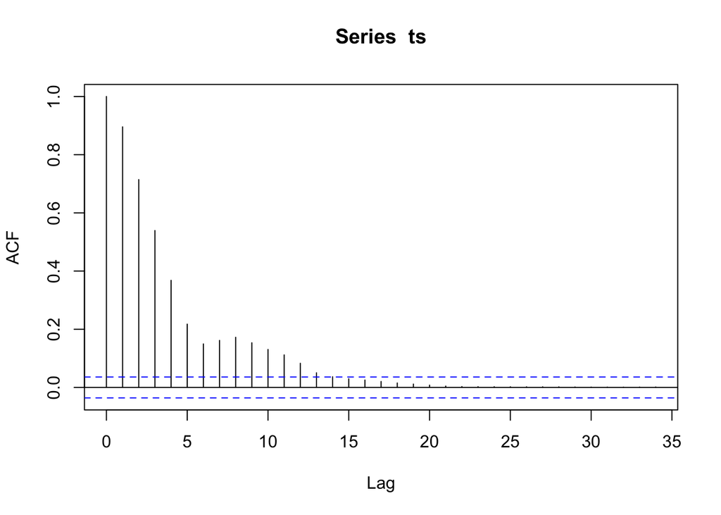

```r
acf(ts)
```

Step 2: Fit an ARIMA to the series to isolate and inspect residuals

```r
arima.fit <- auto.arima(ts, allowdrift = TRUE, allowmean = TRUE,
                        trace = TRUE)
```

```
##
##  Fitting models using approximations to speed things up...
##
##  ARIMA(2,0,2) with non-zero mean : 34661.82
##  ARIMA(0,0,0) with non-zero mean : 40183.01
##  ARIMA(1,0,0) with non-zero mean : 35361.33
##  ARIMA(0,0,1) with non-zero mean : 37159.13
##  ARIMA(0,0,0) with zero mean     : 40304.07
##  ARIMA(1,0,2) with non-zero mean : 34661.29
##  ARIMA(1,0,1) with non-zero mean : 34684.17
##  ARIMA(1,0,3) with non-zero mean : 34663.27
##  ARIMA(2,0,3) with non-zero mean : 34663.69
##  ARIMA(1,0,2) with zero mean     : 34672.02
##  ARIMA(0,0,2) with non-zero mean : 35623.55
##
##  Now re-fitting the best model(s) without approximations...
##
##  ARIMA(1,0,2) with non-zero mean : 34662.42
##
##  Best model: ARIMA(1,0,2) with non-zero mean
```

```r
summary(arima.fit)
```

```
## Series: ts
## ARIMA(1,0,2) with non-zero mean
##
## Coefficients:
##          ar1     ma1     ma2     mean
##       0.7835  0.5764  0.1053  42.4821
## s.e.  0.0148  0.0233  0.0217  11.6131
##
## sigma^2 estimated as 6679:  log likelihood=-17326.2
## AIC=34662.4   AICc=34662.42   BIC=34692.39
##
## Training set error measures:
##                        ME     RMSE      MAE MPE MAPE     MASE        ACF1
## Training set -0.002406434 81.66943 9.839557 NaN  Inf 1.273413 0.000759051
```

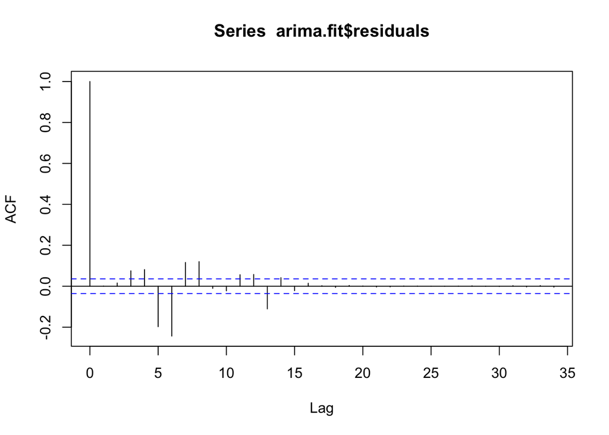

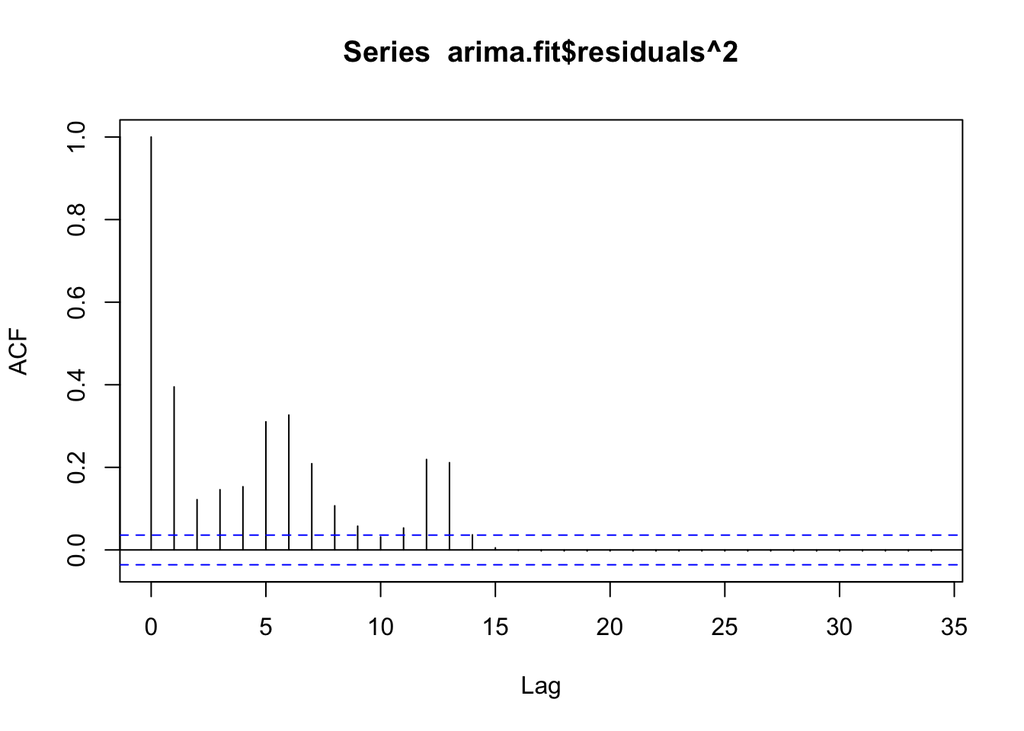

```r
acf(arima.fit$residuals) ; acf(arima.fit$residuals^2)
```

Step 3: Fit a GARCH Model to Residual Series

The below code fits a GARCH model to the residuals. Put simply, the GARCH model will effectively fit an ARMA process to the residuals of the preceding ARIMA model. ACF plots of the GARCH residuals show that the GARCH(0,1) model fits better than GARCH(0,1). However, both models yielded statistically significant coefficients. With this model, the a1 coefficient can be interpreted as the autoregressive residual term, with b1 representing a residual moving average term. Tests of both a GARCH (0,1) and GARCH(1,1) model elucidate a significant a1 coefficient and insignificant b1. As such, we can conclue the electricity series to be conditionally heteroskedastic, following a GARCH (1,0) process.

```r
a.garch1 <- garch(arima.fit$residuals, order=c(0,1), grad="numerical",
                  trace=FALSE)
summary(a.garch1)
```

```
##
## Call:
## garch(x = arima.fit$residuals, order = c(0, 1), grad = "numerical",     trace = FALSE)
##
## Model:
## GARCH(0,1)
##
## Residuals:
##      Min       1Q   Median       3Q      Max
## -3.17563 -0.24505 -0.18342 -0.08867 26.44102
##
## Coefficient(s):
##     Estimate  Std. Error  t value Pr(>|t|)
## a0  22.21115     0.15619    142.2   <2e-16 ***
## a1  19.07161     0.04712    404.8   <2e-16 ***
## ---
## Signif. codes:  0 '***' 0.001 '**' 0.01 '*' 0.05 '.' 0.1 ' ' 1
##
## Diagnostic Tests:
##  Jarque Bera Test
##
## data:  Residuals
## X-squared = 26688000, df = 2, p-value < 2.2e-16
##
##
##  Box-Ljung test
##
## data:  Squared.Residuals
## X-squared = 0.010676, df = 1, p-value = 0.9177
```

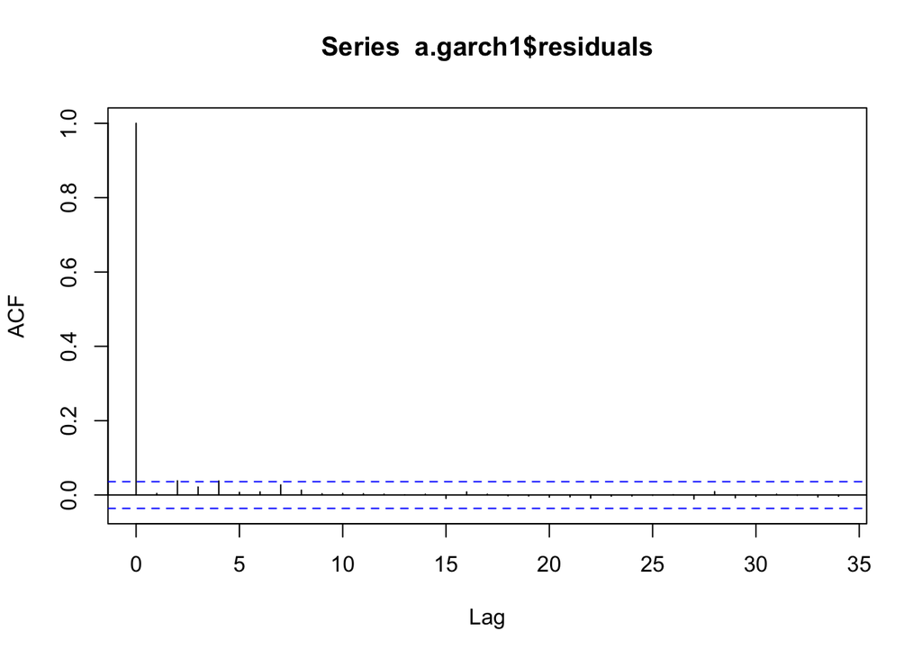

```r
acf(a.garch1$residuals, na.action = na.pass)
```

```r
#Residuals show the 0,1 process is a better fit
a.garch2 <- garch(arima.fit$residuals, grad="numerical",
                  trace=FALSE)
summary(a.garch2)
```

```
##
## Call:
## garch(x = arima.fit$residuals, grad = "numerical", trace = FALSE)
##
## Model:
## GARCH(1,1)
##
## Residuals:
##      Min       1Q   Median       3Q      Max
## -1.48605 -0.03314 -0.02524 -0.01178  6.33626
##
## Coefficient(s):
##     Estimate  Std. Error  t value Pr(>|t|)
## a0 5.904e+03   1.745e+02   33.828   <2e-16 ***
## a1 6.900e+00   7.588e-01    9.094   <2e-16 ***
## b1 1.783e-07   8.035e-04    0.000        1
## ---
## Signif. codes:  0 '***' 0.001 '**' 0.01 '*' 0.05 '.' 0.1 ' ' 1
##
## Diagnostic Tests:
##  Jarque Bera Test
##
## data:  Residuals
## X-squared = 17983000, df = 2, p-value < 2.2e-16
##
##
##  Box-Ljung test
##
## data:  Squared.Residuals
## X-squared = 0.76268, df = 1, p-value = 0.3825
```

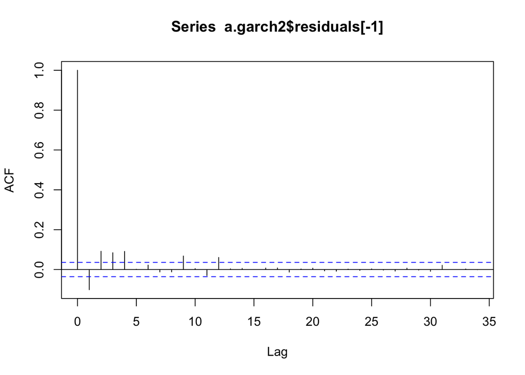

```r
acf(a.garch2$residuals[-1], na.action = na.pass)
```

The output from the above GARCH model can be used to improve forecasts of the original electricity series. GARCH output can help estimate the conditional variance of the series over time. This in turn, can be used to update forecast prediction error.

PART V

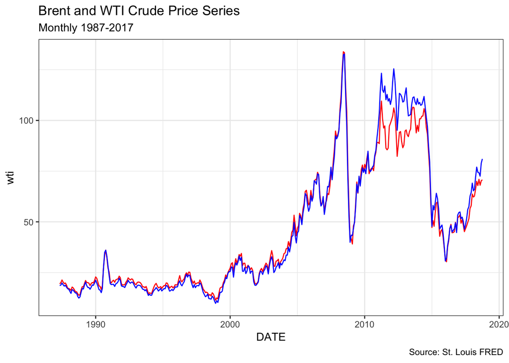

```r
# PART V #

wti <- read.csv("wti_prices.csv")
names(wti)[2] <- "wti"
wti$DATE <- as.Date(wti$DATE, format = "%Y-%m-%d")

brent <- read.csv("brent_prices.csv")
brent$DATE <- as.Date(brent$DATE, format = "%Y-%m-%d")



names(brent)[2] <- "brent"

df <- merge(brent, wti)
df <- na.omit(df)
df$spread <- df$wti - df$brent

ggplot(df, aes(x = DATE, y = wti))+ theme_bw()+
geom_line(color = "red")+ geom_line(aes(y = brent), color = "blue")+
  labs(title = "Brent and WTI Crude Price Series", subtitle = "Monthly 1987-2017", caption = "Source: St. Louis FRED")
```

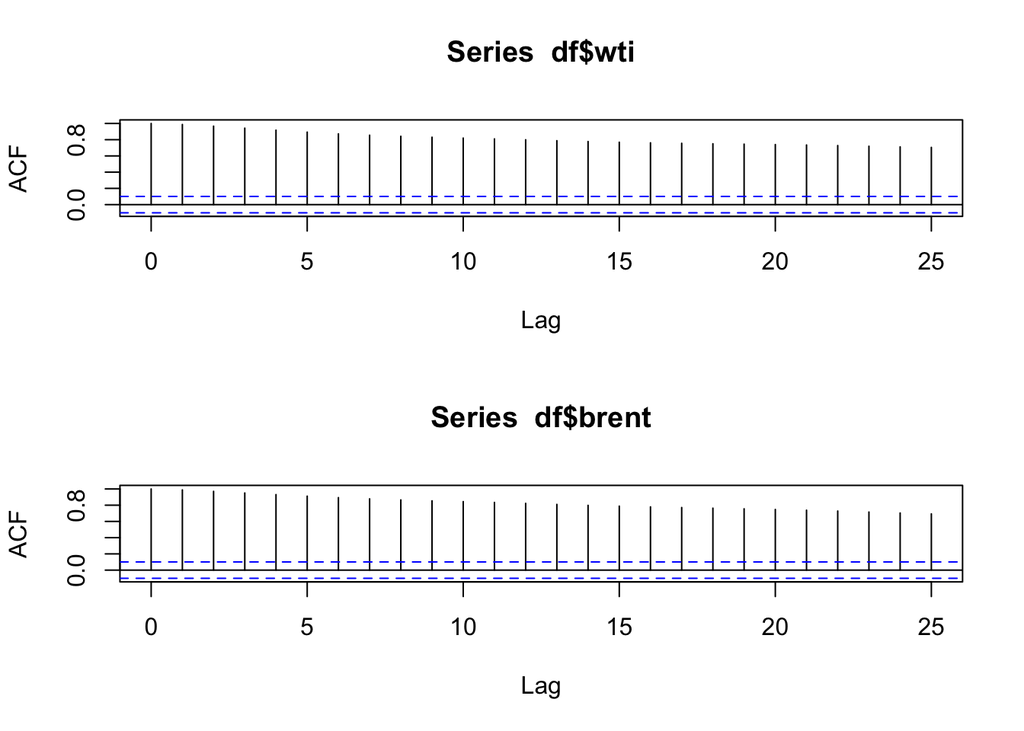

```r
#Let's test each series order of integration
#1987-2018 Range
  #Definitely appear to have a similar acf decay structure
  #Both suggestive of random walk. Near identical PACF as well
layout(1:2)
acf(df$wti); acf(df$brent)
```

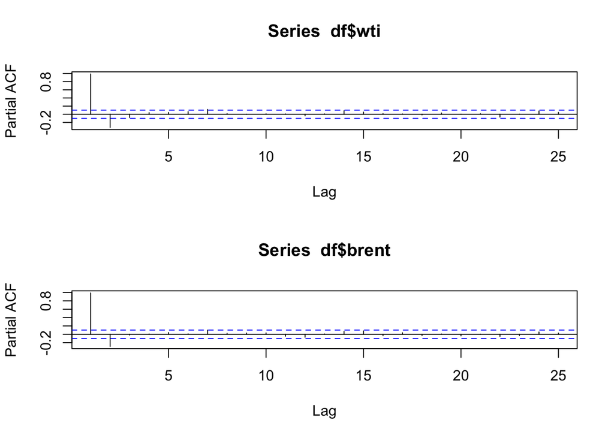

```r
pacf(df$wti); pacf(df$brent)
```

```r
#ADF and PP tests further suggest we are I(1) for both series
adf.test(df$wti); adf.test(df$brent)
```

```
##
##  Augmented Dickey-Fuller Test
##
## data:  df$wti
## Dickey-Fuller = -2.4776, Lag order = 7, p-value = 0.3754
## alternative hypothesis: stationary
```

```
##
##  Augmented Dickey-Fuller Test
##
## data:  df$brent
## Dickey-Fuller = -2.4353, Lag order = 7, p-value = 0.3933
## alternative hypothesis: stationary
```

```r
PP.test(df$wti); PP.test(df$brent)
```

```
##
##  Phillips-Perron Unit Root Test
##
## data:  df$wti
## Dickey-Fuller = -2.9278, Truncation lag parameter = 5, p-value =
## 0.1853
```

```
##
##  Phillips-Perron Unit Root Test
##
## data:  df$brent
## Dickey-Fuller = -2.6834, Truncation lag parameter = 5, p-value =
## 0.2885
```

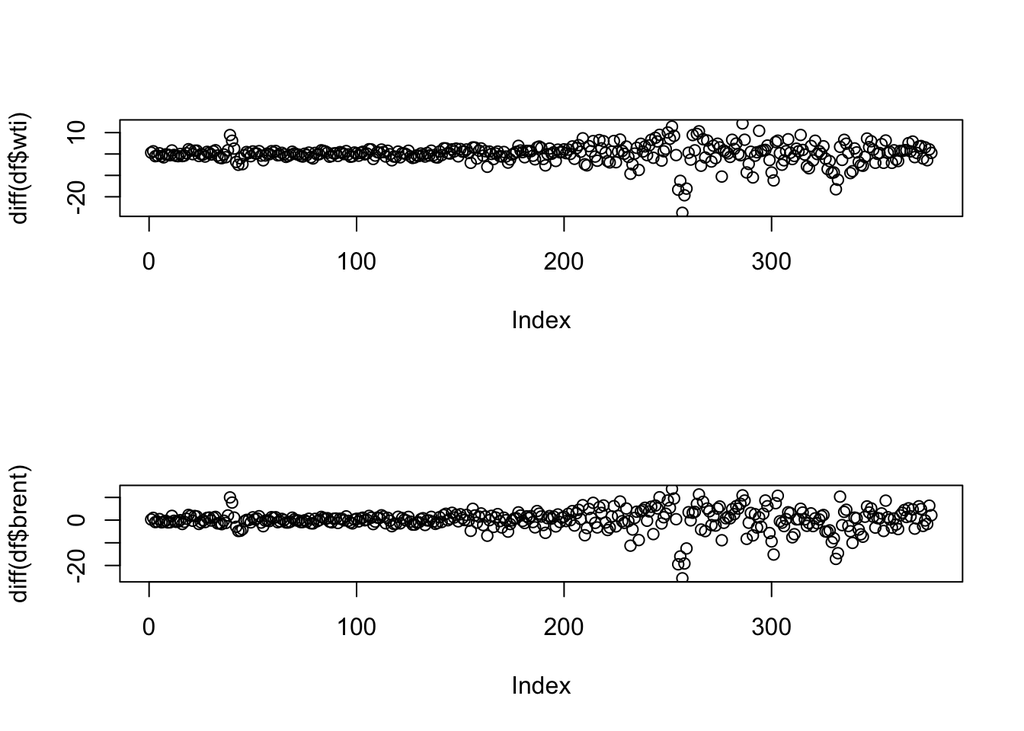

```r
 #First differences return both series to stationary
plot(diff(df$wti));
plot(diff(df$brent))
```

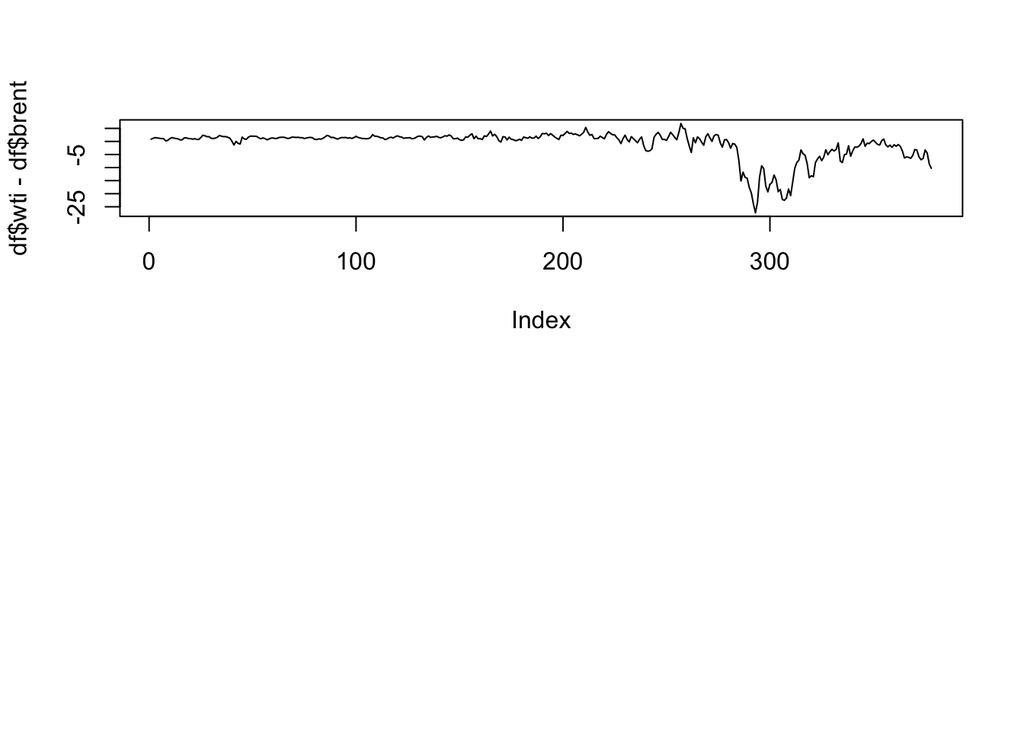

```r
plot(df$wti - df$brent, type = "l")
```

The Phillips-Ouliaris test for the entire series lengths demonstrate that the full series are co-integrated. This should make sense intuitively as the principles of arbitrage suggest disturbances in one series should spillover to the other price series.

```r
po.test(cbind(df$brent, df$wti))
```

```
##
##  Phillips-Ouliaris Cointegration Test
##
## data:  cbind(df$brent, df$wti)
## Phillips-Ouliaris demeaned = -34.951, Truncation lag parameter =
## 3, p-value = 0.01
```

```r
#Subset dataframe to 2005-2017 period



#Create the intervention term.
df$decline <- 0
df[df$DATE > "2010-11-01" ,]$decline = 1

df$reversal <- 0
df[df$DATE > "2012-05-19",]$reversal = 1

df$time <- df$id <- seq(nrow(df))
df$time <- df$time - df[df$DATE == "2012-05-01",]$time
df$post.int <- df$time * df$reversal

post <- df[df$DATE > "2018-01-01",]
df1 <- df[df$DATE > "2004-12-31" & df$DATE < "2018-01-01",]


#Baseline Regression

lm1 <- lm(df1$wti~df1$brent)
#plot(df1$wti, type = "l"); lines(lm$fitted.values, type = "l", col="red")

# Baseline with time trend
lm2 <- lm(df1$wti ~ df1$brent + df1$id)

#Baseline with time trend and reversal dummy
lm3 <- lm(df1$wti ~ df1$brent + df1$id + df1$reversal)

#Baseline with time trend reversal dummy and interaction between time
#and reversal
lm4 <- lm(df1$wti ~ df1$brent + df1$id + df1$reversal + df1$post.int)

#lm3 + decline intervention term
lm5 <-lm(df1$wti ~ df1$brent + df1$time + df1$reversal +
           df1$decline+df1$post.int)

#Run some regressions with our initial intervention date

lm6 <- lm(df1$wti~df1$brent +df1$decline+df1$reversal +
            df1$post.int )
```

The above segment of code applies 6 different linear model specifications with the WTI price series representing the dependent variable. Each regression specification is shown below

1.) $y_t = \beta_1brent_t$

2.) $y_t = \beta_1brent_t + \beta_2time$

3.) $y_t = \beta_1 brent_t + \beta_2 time + \beta_3reversal$

4.) $y_t = \beta_1 *brent_t + \beta_2time + \beta3reversal + \beta4post.intervention$

5.) $y_t = \beta_1 *brent_t + \beta_2time + \beta3reversal + \beta4post.intervention + \beta5decline$

6.) $y_t = \beta_1 *brent_t + \beta3reversal + \beta4post.intervention + \beta5decline$

Where $brent_t$ represents brent prices. $reversal$ and $post.intervention$ are model a post intervention dummy and its interaction with time. Specifications 5 and 6 include a $decline$ term, which represents a dummy intervention beginning in December 2010. The timing of the decline intervention term coincides with the increase in the spread between Brent and WTI crude caused by the rise of the US shale boom.

```r
# summary(lm1)
# summary(lm2)
# summary(lm3)
# summary (lm4)
# summary (lm5)
summary(lm6)
```

```
##
## Call:
## lm(formula = df1$wti ~ df1$brent + df1$decline + df1$reversal +
##     df1$post.int)
##
## Residuals:
##      Min       1Q   Median       3Q      Max
## -11.8345  -1.5364   0.3254   2.0086  12.4590
##
## Coefficients:
##               Estimate Std. Error t value Pr(>|t|)
## (Intercept)    3.36570    1.32585   2.539   0.0121 *
## df1$brent      0.96649    0.01753  55.134  < 2e-16 ***
## df1$decline  -15.05989    1.20627 -12.485  < 2e-16 ***
## df1$reversal   1.30506    1.26820   1.029   0.3051
## df1$post.int   0.19603    0.03214   6.098 8.59e-09 ***
## ---
## Signif. codes:  0 '***' 0.001 '**' 0.01 '*' 0.05 '.' 0.1 ' ' 1
##
## Residual standard error: 3.699 on 151 degrees of freedom
## Multiple R-squared:  0.9744, Adjusted R-squared:  0.9737
## F-statistic:  1434 on 4 and 151 DF,  p-value: < 2.2e-16
```

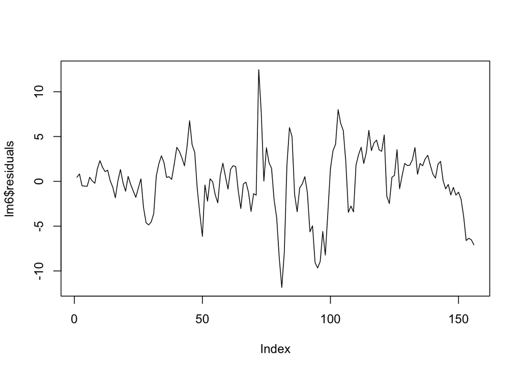

```r
plot(lm6$residuals, type = "l")
```

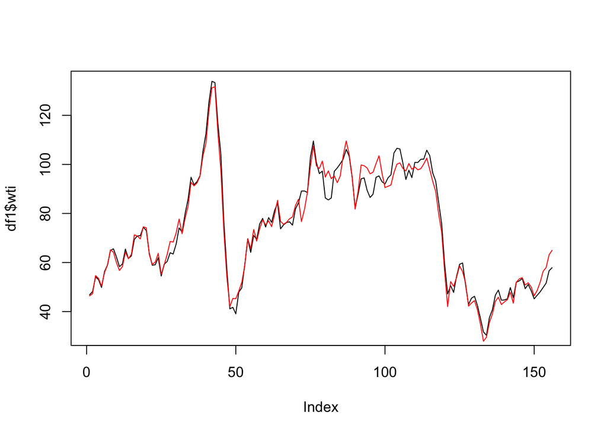

```r
plot(df1$wti, type = "l"); lines(x = seq(length(df1$wti)), y = lm6$fitted.values, type = "l", col = "red")
```

ACF plots of the preffered linear model demonstrate residual autocorrelation. This suggests that a model with ARMA errors could provide a better fit. In fact acf and fitted plots of an ARIMAX model featuring the exogenous regressors from the preffered regression specification demonstrate a better fit with no significant residual autocorrelation. Interestingly, pipeline reversal and intevention interaction coefficients of the ARIMAX model are not statistically significant, suggesting the pipeline reversal has had no effect on WTI prices. It’s possible that negative price pressures associated with macro events occuring in the wake of the pipeline reversal, such as the growth slowdown in China and increase in US shale oil production, have outweighed the theorized positive effects of the pipeline reversal.

```r
xreg <- df1[c("reversal", "brent", "decline", "post.int")]
arima1 <- auto.arima(df1$wti, xreg = xreg, allowmean = TRUE)
summary(arima1)
```

```
## Series: df1$wti
## Regression with ARIMA(1,0,1) errors
##
## Coefficients:
##          ar1    ma1  intercept  reversal   brent  decline  post.int
##       0.8237  0.208     6.8638   -0.1332  0.8861  -3.8431    0.0045
## s.e.  0.0695  0.080     2.8831    2.1947  0.0290   2.7849    0.0790
##
## sigma^2 estimated as 5.366:  log likelihood=-349.56
## AIC=715.13   AICc=716.11   BIC=739.53
##
## Training set error measures:
##                       ME     RMSE      MAE         MPE     MAPE      MASE
## Training set -0.00401736 2.263852 1.682161 -0.08817453 2.346484 0.3639922
##                   ACF1
## Training set 0.0234475
```

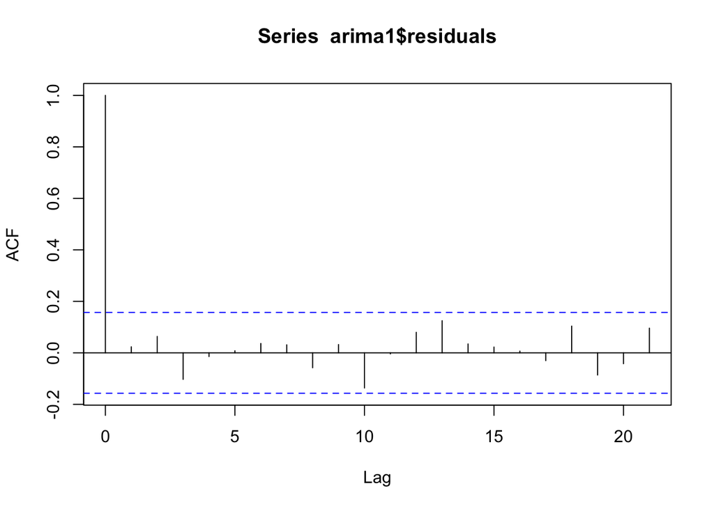

```r
acf(arima1$residuals)
```

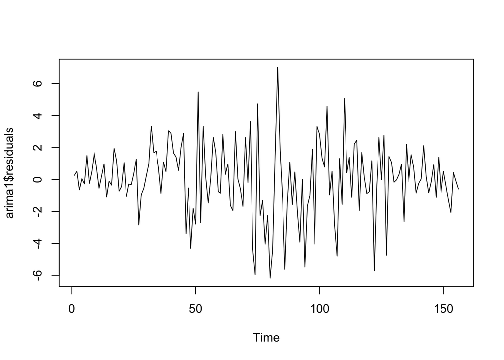

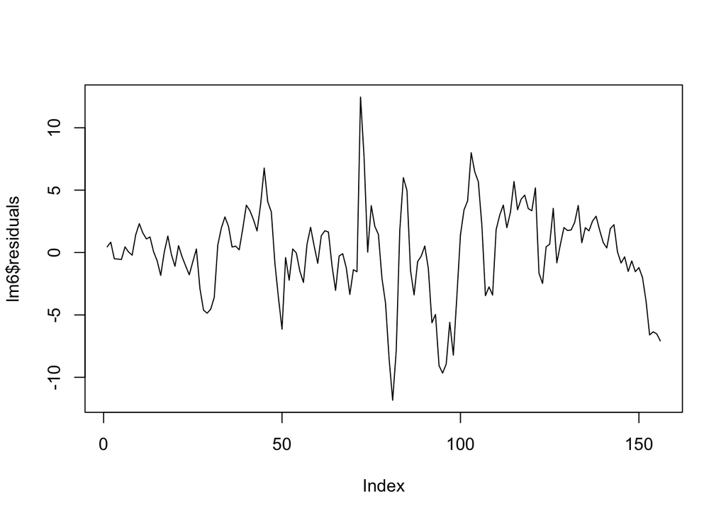

```r
plot(arima1$residuals); plot(lm6$residuals, type = "l")
```

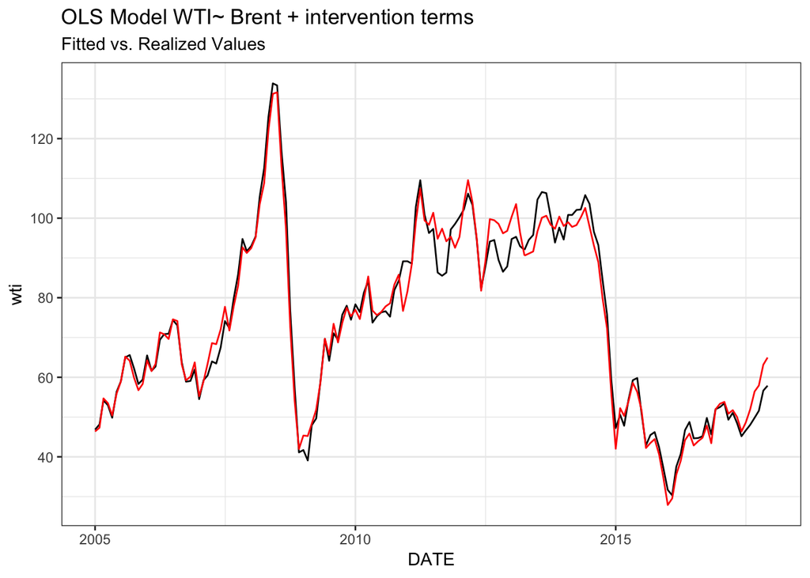

```r
ggplot(df1, aes(x = DATE, y = wti))+ geom_line() + theme_bw()+
labs(title = "OLS Model WTI~ Brent + intervention terms", subtitle ="Fitted vs. Realized Values") + geom_line(aes(y = lm6$fitted.values), color = "red")
```

```r
#Let's assume brent remains constant and forecast 9 steps
brent <- rep(df1$brent[156],9)
post.int <- seq(157:165)
reversal <- rep(1,9)
decline <- rep(1,9)
df1 <- data.frame(brent,post.int,reversal,decline)
forecast.lm6 <- predict(lm6, df1, n.ahead = 9)
```